# MEDBS datacall Report

## 5.1 Catch data time series

### 5.1.1 GSA 18

#### 5.1.1.1 ANE

*Coverage of landing data for ANE in GSA 18*

| country | year | area | species | landings |
| --- | --- | --- | --- | --- |
| ITA | 2006 | GSA 18 | ANE | 4680.107 |
| ITA | 2007 | GSA 18 | ANE | 12779.651 |
| ITA | 2008 | GSA 18 | ANE | 9493.194 |
| ITA | 2009 | GSA 18 | ANE | 6958.050 |
| ITA | 2010 | GSA 18 | ANE | 6735.869 |
| ITA | 2011 | GSA 18 | ANE | 1881.048 |
| ITA | 2012 | GSA 18 | ANE | 6617.349 |
| ITA | 2013 | GSA 18 | ANE | 1388.028 |
| ITA | 2014 | GSA 18 | ANE | 3330.038 |
| ITA | 2015 | GSA 18 | ANE | 5683.567 |
| ITA | 2016 | GSA 18 | ANE | 5580.362 |
| ITA | 2017 | GSA 18 | ANE | 7303.034 |
| ITA | 2018 | GSA 18 | ANE | 6947.839 |
| ITA | 2019 | GSA 18 | ANE | 2252.882 |
| ITA | 2020 | GSA 18 | ANE | 3421.080 |
| ITA | 2021 | GSA 18 | ANE | 1313.040 |
| ITA | 2022 | GSA 18 | ANE | 252.412 |

*Coverage of landing data for DPS in GSA 18*

| country | year | area | species | landings |
| --- | --- | --- | --- | --- |
| ITA | 2002 | GSA 18 | DPS | 1147.2371 |
| ITA | 2003 | GSA 18 | DPS | 1816.0024 |
| ITA | 2004 | GSA 18 | DPS | 1857.4292 |
| ITA | 2005 | GSA 18 | DPS | 1181.4778 |
| ITA | 2006 | GSA 18 | DPS | 1473.1758 |
| ITA | 2007 | GSA 18 | DPS | 863.0675 |
| ITA | 2008 | GSA 18 | DPS | 766.2032 |
| ITA | 2009 | GSA 18 | DPS | 939.4419 |
| ITA | 2010 | GSA 18 | DPS | 888.0992 |
| ITA | 2011 | GSA 18 | DPS | 869.6281 |
| ITA | 2012 | GSA 18 | DPS | 522.8342 |
| ITA | 2013 | GSA 18 | DPS | 733.7246 |
| ITA | 2014 | GSA 18 | DPS | 637.7358 |
| ITA | 2015 | GSA 18 | DPS | 651.2741 |
| ITA | 2016 | GSA 18 | DPS | 996.3795 |
| ITA | 2017 | GSA 18 | DPS | 1109.3610 |
| ITA | 2018 | GSA 18 | DPS | 1961.9648 |
| ITA | 2019 | GSA 18 | DPS | 2186.9856 |
| ITA | 2020 | GSA 18 | DPS | 1835.0299 |
| ITA | 2021 | GSA 18 | DPS | 1679.0153 |
| ITA | 2022 | GSA 18 | DPS | 1001.0380 |

*Coverage of discard data for DPS in GSA 18*

| country | year | area | species | discards |
| --- | --- | --- | --- | --- |
| ITA | 2009 | GSA 18 | DPS | 30.83697 |
| ITA | 2010 | GSA 18 | DPS | 17.52799 |
| ITA | 2011 | GSA 18 | DPS | 5.27103 |
| ITA | 2012 | GSA 18 | DPS | 7.20127 |
| ITA | 2013 | GSA 18 | DPS | 12.28552 |
| ITA | 2014 | GSA 18 | DPS | 7.70791 |
| ITA | 2015 | GSA 18 | DPS | 13.88002 |
| ITA | 2016 | GSA 18 | DPS | 20.80623 |
| ITA | 2017 | GSA 18 | DPS | 42.26301 |
| ITA | 2018 | GSA 18 | DPS | 51.95010 |
| ITA | 2019 | GSA 18 | DPS | 94.10733 |
| ITA | 2020 | GSA 18 | DPS | 6.45981 |
| ITA | 2021 | GSA 18 | DPS | 4.12528 |
| ITA | 2022 | GSA 18 | DPS | 8.62776 |

#### 5.1.1.2 HKE

*Coverage of landing data for HKE in GSA 18*

| country | year | area | species | landings |
| --- | --- | --- | --- | --- |
| ITA | 2002 | GSA 18 | HKE | 2309.142 |
| ITA | 2003 | GSA 18 | HKE | 4450.769 |
| ITA | 2004 | GSA 18 | HKE | 3204.111 |
| ITA | 2005 | GSA 18 | HKE | 3784.651 |
| ITA | 2006 | GSA 18 | HKE | 5506.318 |
| ITA | 2007 | GSA 18 | HKE | 4154.556 |
| ITA | 2008 | GSA 18 | HKE | 4247.904 |
| ITA | 2009 | GSA 18 | HKE | 4105.819 |
| ITA | 2010 | GSA 18 | HKE | 4020.612 |
| ITA | 2011 | GSA 18 | HKE | 3849.697 |
| ITA | 2012 | GSA 18 | HKE | 3105.702 |
| ITA | 2013 | GSA 18 | HKE | 2566.947 |
| ITA | 2014 | GSA 18 | HKE | 1863.625 |
| ITA | 2015 | GSA 18 | HKE | 2040.697 |
| ITA | 2016 | GSA 18 | HKE | 2194.563 |
| ITA | 2017 | GSA 18 | HKE | 2230.520 |
| ITA | 2018 | GSA 18 | HKE | 2000.253 |
| ITA | 2019 | GSA 18 | HKE | 1722.238 |
| ITA | 2020 | GSA 18 | HKE | 1353.534 |
| ITA | 2021 | GSA 18 | HKE | 1389.242 |
| ITA | 2022 | GSA 18 | HKE | 1190.625 |

*Coverage of discard data for HKE in GSA 18*

| country | year | area | species | discards |
| --- | --- | --- | --- | --- |
| ITA | 2009 | GSA 18 | HKE | 151.60242 |
| ITA | 2010 | GSA 18 | HKE | 77.86157 |
| ITA | 2011 | GSA 18 | HKE | 99.69113 |
| ITA | 2012 | GSA 18 | HKE | 177.32864 |
| ITA | 2013 | GSA 18 | HKE | 15.36081 |
| ITA | 2014 | GSA 18 | HKE | 46.79378 |
| ITA | 2015 | GSA 18 | HKE | 86.24911 |
| ITA | 2016 | GSA 18 | HKE | 107.10148 |
| ITA | 2017 | GSA 18 | HKE | 31.43257 |
| ITA | 2018 | GSA 18 | HKE | 55.88577 |
| ITA | 2019 | GSA 18 | HKE | 102.13291 |
| ITA | 2020 | GSA 18 | HKE | 18.97022 |
| ITA | 2021 | GSA 18 | HKE | 22.57761 |
| ITA | 2022 | GSA 18 | HKE | 30.72273 |

#### 5.1.1.3 MUT

*Coverage of landing data for MUT in GSA 18*

| country | year | area | species | landings |
| --- | --- | --- | --- | --- |
| ITA | 2002 | GSA 18 | MUT | 4911.0729 |
| ITA | 2003 | GSA 18 | MUT | 2369.5173 |
| ITA | 2004 | GSA 18 | MUT | 2063.6247 |
| ITA | 2005 | GSA 18 | MUT | 1449.5258 |
| ITA | 2006 | GSA 18 | MUT | 1934.4207 |
| ITA | 2007 | GSA 18 | MUT | 1802.1985 |
| ITA | 2008 | GSA 18 | MUT | 960.8178 |
| ITA | 2009 | GSA 18 | MUT | 1031.2898 |
| ITA | 2010 | GSA 18 | MUT | 646.1816 |
| ITA | 2011 | GSA 18 | MUT | 531.7451 |
| ITA | 2012 | GSA 18 | MUT | 2096.2806 |
| ITA | 2013 | GSA 18 | MUT | 1249.8088 |
| ITA | 2014 | GSA 18 | MUT | 1272.2093 |
| ITA | 2015 | GSA 18 | MUT | 1587.3724 |
| ITA | 2016 | GSA 18 | MUT | 1448.0467 |
| ITA | 2017 | GSA 18 | MUT | 619.5062 |
| ITA | 2018 | GSA 18 | MUT | 1003.8538 |
| ITA | 2019 | GSA 18 | MUT | 774.6109 |
| ITA | 2020 | GSA 18 | MUT | 466.4998 |
| ITA | 2021 | GSA 18 | MUT | 678.6312 |
| ITA | 2022 | GSA 18 | MUT | 331.8110 |

*Coverage of discard data for MUT in GSA 18*

| country | year | area | species | discards |
| --- | --- | --- | --- | --- |
| ITA | 2009 | GSA 18 | MUT | 14.73368 |
| ITA | 2010 | GSA 18 | MUT | 35.00665 |
| ITA | 2011 | GSA 18 | MUT | 19.30206 |
| ITA | 2012 | GSA 18 | MUT | 434.05257 |
| ITA | 2013 | GSA 18 | MUT | 19.43610 |
| ITA | 2014 | GSA 18 | MUT | 119.61623 |
| ITA | 2015 | GSA 18 | MUT | 89.36626 |
| ITA | 2016 | GSA 18 | MUT | 87.41031 |
| ITA | 2017 | GSA 18 | MUT | 13.16708 |
| ITA | 2018 | GSA 18 | MUT | 182.86968 |
| ITA | 2019 | GSA 18 | MUT | 198.03616 |
| ITA | 2020 | GSA 18 | MUT | 20.98316 |
| ITA | 2021 | GSA 18 | MUT | 19.51998 |
| ITA | 2022 | GSA 18 | MUT | 0.39619 |

#### 5.1.1.4 NEP

*Coverage of landing data for NEP in GSA 18*

| country | year | area | species | landings |
| --- | --- | --- | --- | --- |
| ITA | 2002 | GSA 18 | NEP | 478.4735 |
| ITA | 2003 | GSA 18 | NEP | 1186.5499 |
| ITA | 2004 | GSA 18 | NEP | 1218.4303 |
| ITA | 2005 | GSA 18 | NEP | 1198.6758 |
| ITA | 2006 | GSA 18 | NEP | 1446.6474 |
| ITA | 2007 | GSA 18 | NEP | 1314.6344 |
| ITA | 2008 | GSA 18 | NEP | 1012.7997 |
| ITA | 2009 | GSA 18 | NEP | 1092.8944 |
| ITA | 2010 | GSA 18 | NEP | 1023.4234 |
| ITA | 2011 | GSA 18 | NEP | 759.1686 |
| ITA | 2012 | GSA 18 | NEP | 458.7038 |
| ITA | 2013 | GSA 18 | NEP | 833.8332 |
| ITA | 2014 | GSA 18 | NEP | 444.7174 |
| ITA | 2015 | GSA 18 | NEP | 442.7534 |
| ITA | 2016 | GSA 18 | NEP | 395.0724 |
| ITA | 2017 | GSA 18 | NEP | 556.1779 |
| ITA | 2018 | GSA 18 | NEP | 650.5859 |
| ITA | 2019 | GSA 18 | NEP | 375.5174 |
| ITA | 2020 | GSA 18 | NEP | 160.6778 |
| ITA | 2021 | GSA 18 | NEP | 129.4964 |
| ITA | 2022 | GSA 18 | NEP | 46.4970 |

*Coverage of discard data for NEP in GSA 18*

| country | year | area | species | discards |
| --- | --- | --- | --- | --- |
| ITA | 2009 | GSA 18 | NEP | 66.77355 |
| ITA | 2010 | GSA 18 | NEP | 6.22691 |
| ITA | 2011 | GSA 18 | NEP | 0.82838 |
| ITA | 2012 | GSA 18 | NEP | 3.99443 |
| ITA | 2013 | GSA 18 | NEP | 2.27312 |
| ITA | 2014 | GSA 18 | NEP | 5.06619 |
| ITA | 2015 | GSA 18 | NEP | 2.05404 |
| ITA | 2016 | GSA 18 | NEP | 0.74212 |
| ITA | 2017 | GSA 18 | NEP | 2.94963 |
| ITA | 2018 | GSA 18 | NEP | 3.58702 |
| ITA | 2019 | GSA 18 | NEP | 0.09249 |
| ITA | 2020 | GSA 18 | NEP | 0.19119 |
| ITA | 2021 | GSA 18 | NEP | 0.00000 |
| ITA | 2022 | GSA 18 | NEP | 0.00000 |

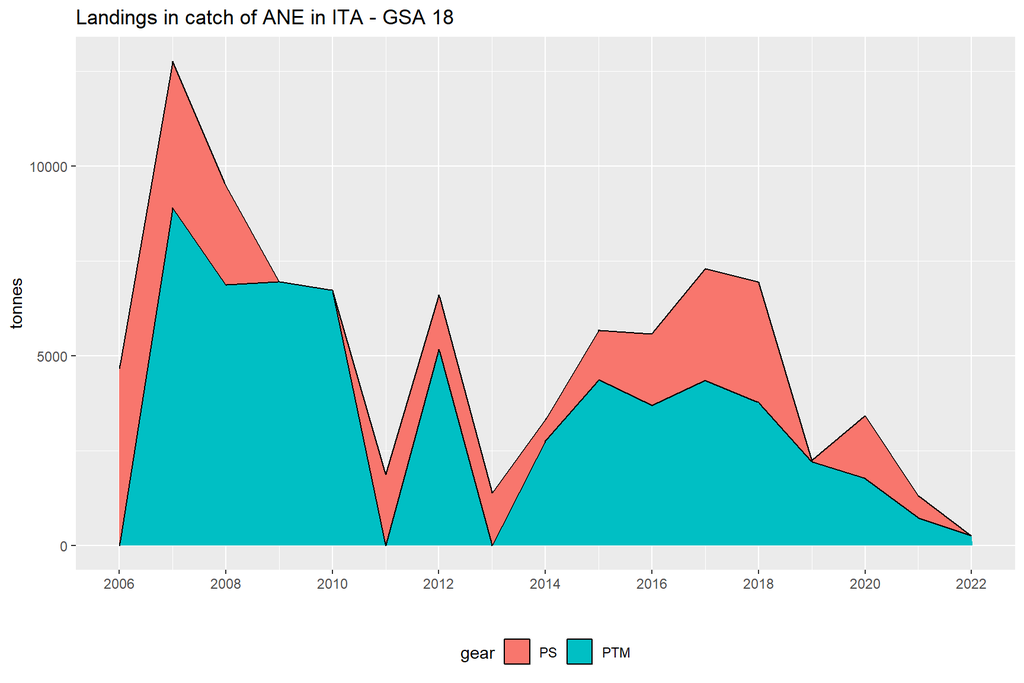

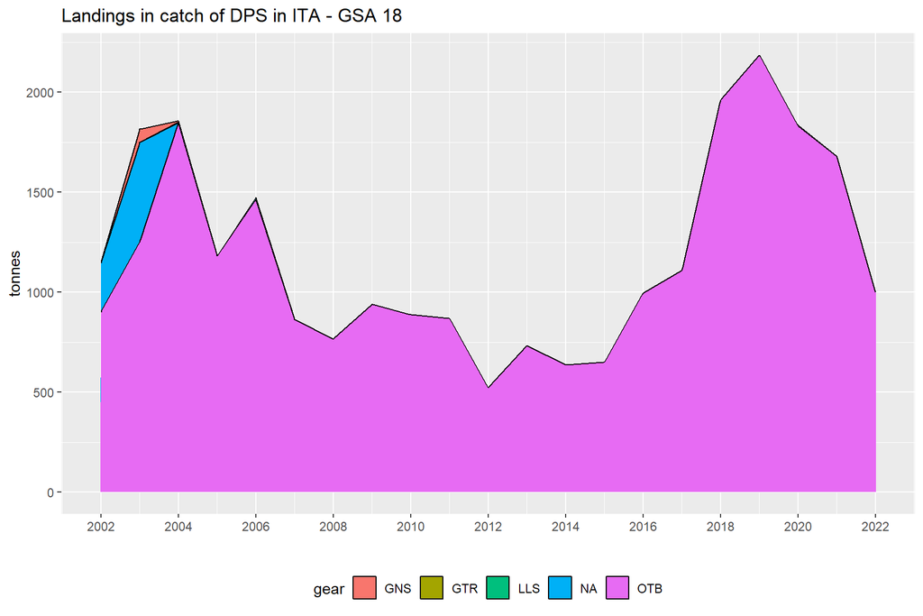

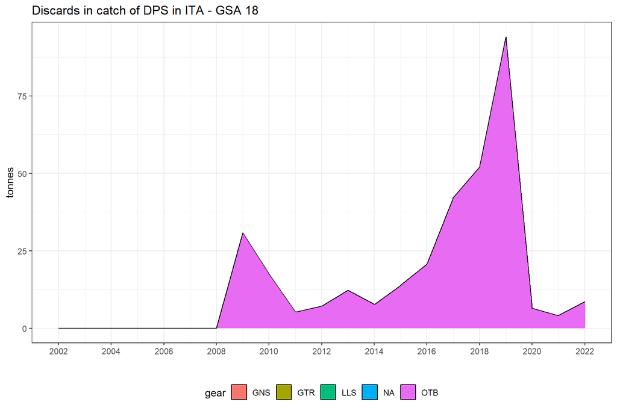

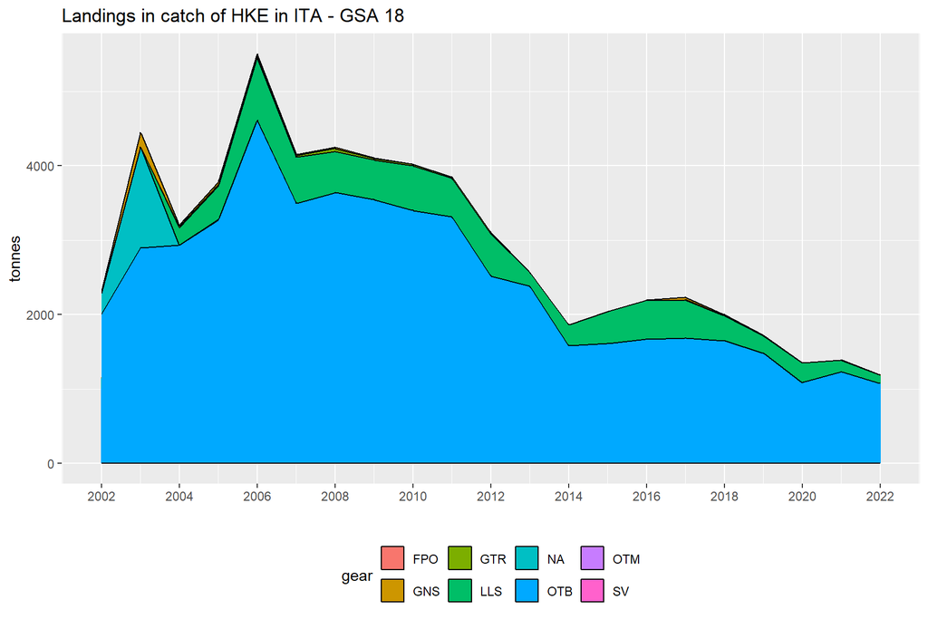

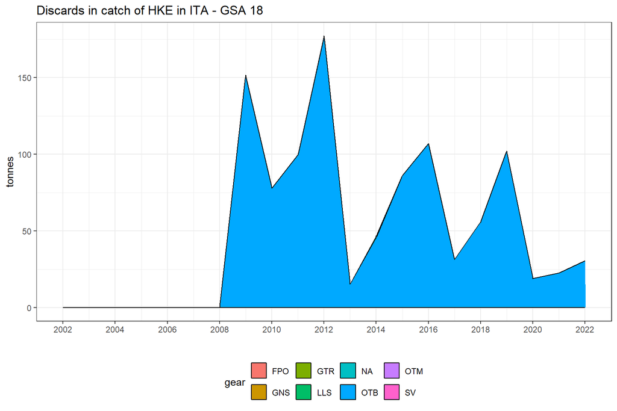

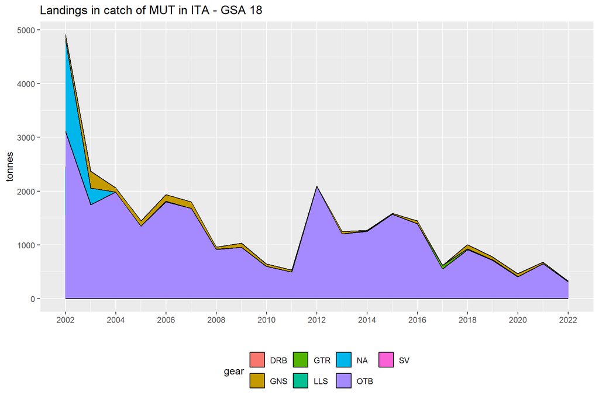

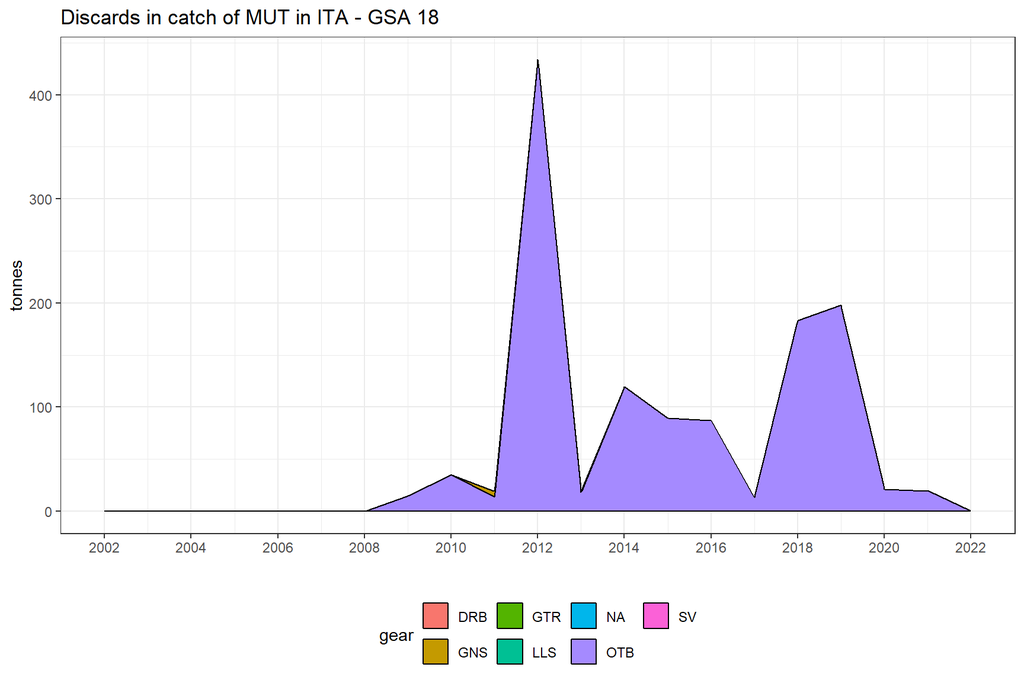

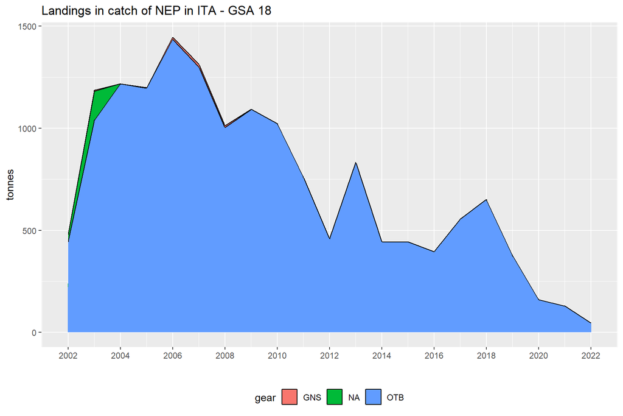

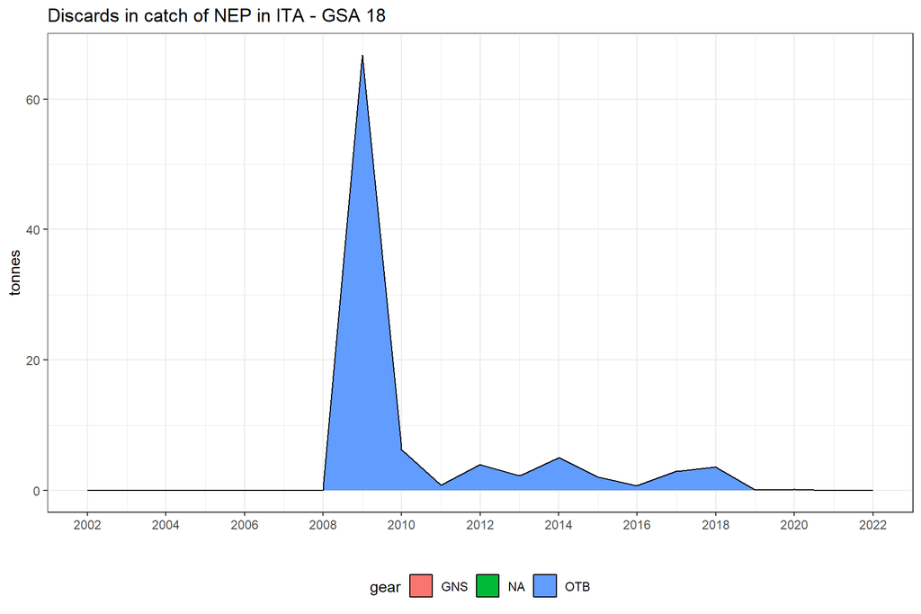